# Time Series Analysis, Case 6

Andew, Carmen, Jimmy, Naresh

23 January 2016

We are going to analyze six simulated time series, and in all of them we have to decide, in a visual and graphical way, if they are or not Covariance-Stationary (CS), White Noise (WN), Strict White Noise (SWN) or Gaussian White Noise (GWN). We will also analyze the real time series for the daily Brent Dated spot prices and its corresponding returns.

# Loading data

First, we load the two datasets

```r
getwd()
```

```
## [1] "/Users/nareshshah/Downloads/ie_time_series_grp_e-master"
```

```r
setwd("/Users/nareshshah/downloads")
library(ggplot2)
library(gridExtra)
real = read.csv("Session6real.csv", sep = "",dec = ",")
names(real) = "price"
sim = read.csv("Session6sim.csv", sep = ";",dec = ",")
```

## Analysis of the Real Data

We need to add a difference value that look at the difference between the price and the previous day. To do this we create a lag of t-1 and then calculate the different.

```r
library(dplyr)
```

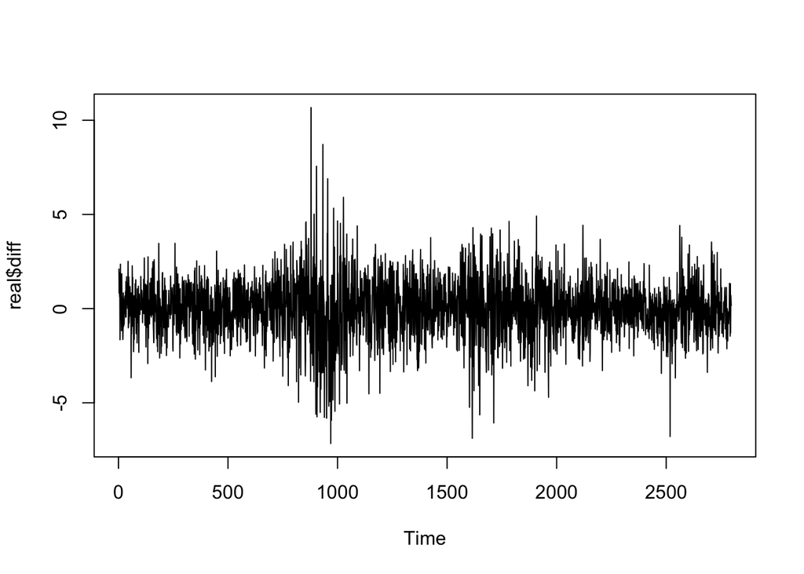

```r
real$lag = lag(real$price,1)
real$diff = real$price - real$lag
ts.plot(real$diff)
```

### Step 1. Plot the series and compute basic statistics

First we compute the mean, standard deviation and the variance of the time series. We then plot the series and see the data is not stationary. The variance is different across the time series so can assume it is not stationary (is this right guys?).

```r
summary(real$price)
```

```
##    Min. 1st Qu.  Median    Mean 3rd Qu.    Max.
##   33.66   60.74   77.88   82.89  108.30  144.20
```

```r
sd(real$price)
```

```
## [1] 25.30475
```

```r
var(real$price)
```

```
## [1] 640.3306
```

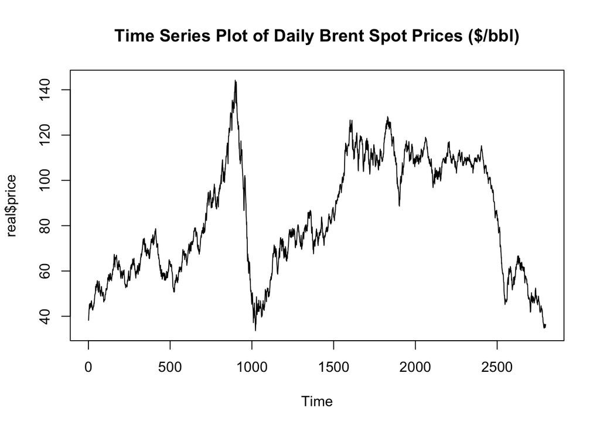

```r
ts.plot(real$price, main = "Time Series Plot of Daily Brent Spot Prices ($/bbl)")
```

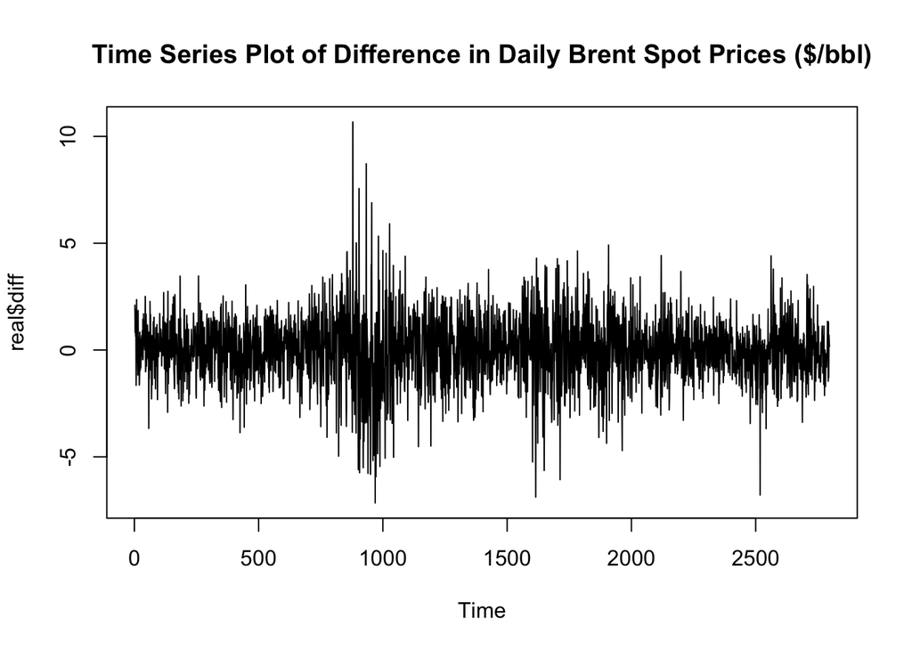

```r
ts.plot(real$diff, main = "Time Series Plot of Difference in Daily Brent Spot Prices ($/bbl)")
```